# Graded Novelty Encoding Task - pilot analysis

# The study

### Familiarization phase

Participants see 5 stimuli repeated 8 times each. Stimuli consist of a 3x3 grid, with 5 random shapes (circle,triangle,square) placed randomly (any 9 cells) with random color (red,blue,yellow,green,orange,purple).

### Study phase

Participants see the 5 familiar stimuli 5 times each (25) and 50 novel stimuli. They have to judge if the current stimulus is one of the familiars. The novels differ to a differing degree from the familiars: there is 5x2 (two for each familiar) that is wholly different (diffarr). 5x2 that has the same placement of random shapes (sarr), 5x2 same arrangement and shapes (sarrsha), 5x2 same arrangement and colors (sarrcol) 5x2 same arrangement, shapes and colors (colors are randomized, thus, these are not the same as the familiars - sarrshacol).

### Test phase

Participants see the novels from the study phase and 50 new stimuli (sarr - 10, sarrsha - 10, etc.). Participants have to signal if they have already seen the current stimulus or it is wholly new. They had the option to signal “maybe”, but were asked to do this in moderation (maybe resp <= 20). These responses have been added to correct responses.

## Participants

The online task has been started a total of 152 times.

We excluded a total of 11 runs due to irregular data leaving 141 in the analysis.

We excluded some (6) runs as they missed more than 66 of 175 trials.

We also excluded 30 runs in which the participant recognized less than half of the prototypes in the study phase.

We also excluded 17 participants as they overused “maybe” responses in the test phase (more than 25).

We also excluded 1 run(s) as only the first run is kept in the analysis from one participant.

This left a total of 87 participants.

Maybe responses [mean(±sd)] : 10.0681818 ± 6.8006008

The sample had a mean(±sd) age of 24.5232558 ± 6.7278643.

The histogram below shows the number of participants completing the task in a given hour of the day.

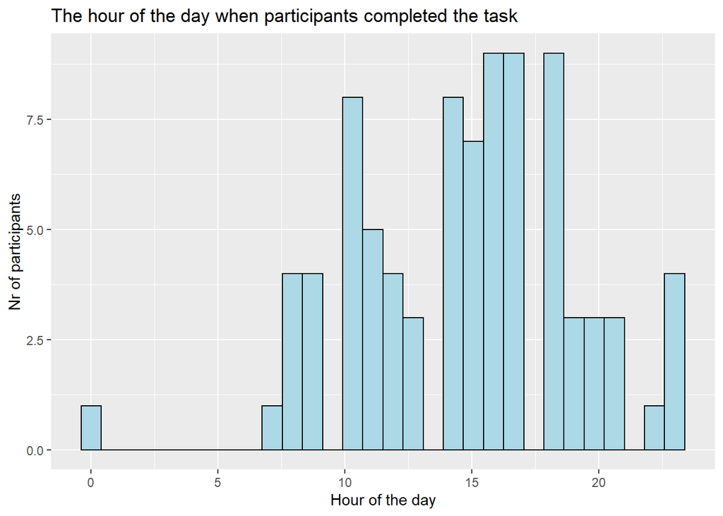

## Study phase:

During the study phase, the participants see familiar and novel items.

The participants produced a mean (±sd) recognition rate of 0.7163218 ± 0.1129132 for familiar pictures.

The sample performed above chance levels, as a one sample t-test showed (t(173)=25.2714487, p = 5.813528810^{-60}, Cohen’s d = 1.9158236, 95% CI:1.5543723 - 2.2772748).

We use an ANOVA to see if there is a difference in correct rejection for the different novels.

```
## Anova Table (Type 3 tests)
##
## Response: N
##   Effect           df  MSE         F  ges p.value
## 1   type 3.67, 315.23 1.90 32.39 *** .116   <.001
## ---
## Signif. codes:  0 '***' 0.001 '**' 0.01 '*' 0.05 '+' 0.1 ' ' 1
##
## Sphericity correction method: GG
```

```
##  contrast             estimate  SE  df t.ratio p.value
##  diffarr - sarr          1.207 0.2 344  6.030  <.0001
##  diffarr - sarrcol       1.115 0.2 344  5.571  <.0001
##  diffarr - sarrsha       2.264 0.2 344 11.314  <.0001
##  diffarr - sarrshacol    0.966 0.2 344  4.824  <.0001
##  sarr - sarrcol         -0.092 0.2 344 -0.459  0.9908
##  sarr - sarrsha          1.057 0.2 344  5.283  <.0001
##  sarr - sarrshacol      -0.241 0.2 344 -1.206  0.7479
##  sarrcol - sarrsha       1.149 0.2 344  5.743  <.0001
##  sarrcol - sarrshacol   -0.149 0.2 344 -0.747  0.9453
##  sarrsha - sarrshacol   -1.299 0.2 344 -6.489  <.0001
##
## P value adjustment: tukey method for comparing a family of 5 estimates
```

```
##  contrast  estimate    SE  df t.ratio p.value
##  linear       -2.99 0.448 344 -6.678  <.0001
##  quadratic     3.77 0.530 344  7.120  <.0001
##  cubic         1.15 0.448 344  2.568  0.0106
##  quartic       6.23 1.184 344  5.261  <.0001
```

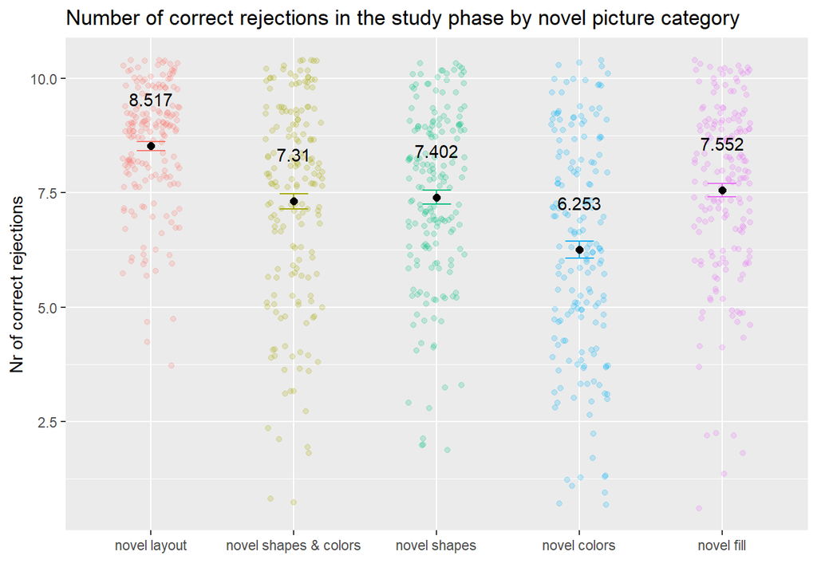

## Test phase:

```
## [1] "A t-test to compare the number of old responses btwn old and new stim"
```

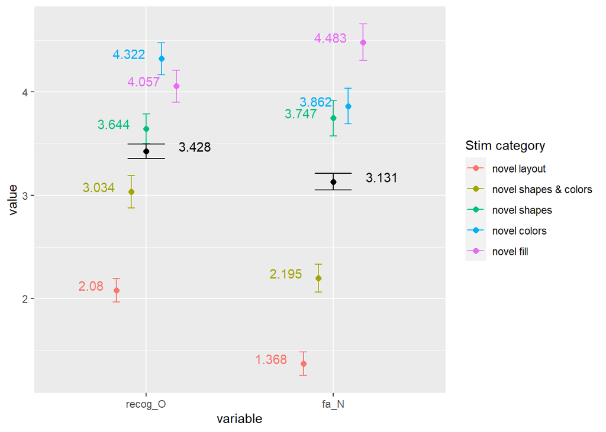

Results of the paired t-test: (t(869)=4.5486395, p = 6.166163310^{-6}, Cohen’s d = 0.1325932, 95% CI:0.0751696 - 0.1900169).

Shapiro-Wilk is significant (p = 4.490632310^{-13}).

```
## Anova Table (Type 3 tests)
##
## Response: CorrRecog
##   Effect           df  MSE        F  ges p.value
## 1   type 3.70, 318.02 3.64 7.60 *** .064   <.001
## ---
## Signif. codes:  0 '***' 0.001 '**' 0.01 '*' 0.05 '+' 0.1 ' ' 1
##
## Sphericity correction method: GG
```

```
##  contrast             estimate    SE  df t.ratio p.value
##  diffarr - sarr         -0.126 0.278 344 -0.455  0.9912
##  diffarr - sarrcol       0.816 0.278 344  2.935  0.0291
##  diffarr - sarrsha       0.253 0.278 344  0.909  0.8932
##  diffarr - sarrshacol    1.138 0.278 344  4.092  0.0005
##  sarr - sarrcol          0.943 0.278 344  3.390  0.0070
##  sarr - sarrsha          0.379 0.278 344  1.364  0.6511
##  sarr - sarrshacol       1.264 0.278 344  4.547  0.0001
##  sarrcol - sarrsha      -0.563 0.278 344 -2.026  0.2560
##  sarrcol - sarrshacol    0.322 0.278 344  1.157  0.7755
##  sarrsha - sarrshacol    0.885 0.278 344  3.183  0.0137
##
## P value adjustment: tukey method for comparing a family of 5 estimates
```

```
##  contrast  estimate    SE  df t.ratio p.value
##  linear      -2.655 0.622 344 -4.270  <.0001
##  quadratic   -0.517 0.736 344 -0.703  0.4825
##  cubic       -0.379 0.622 344 -0.610  0.5422
##  quartic     -5.529 1.645 344 -3.361  0.0009
```

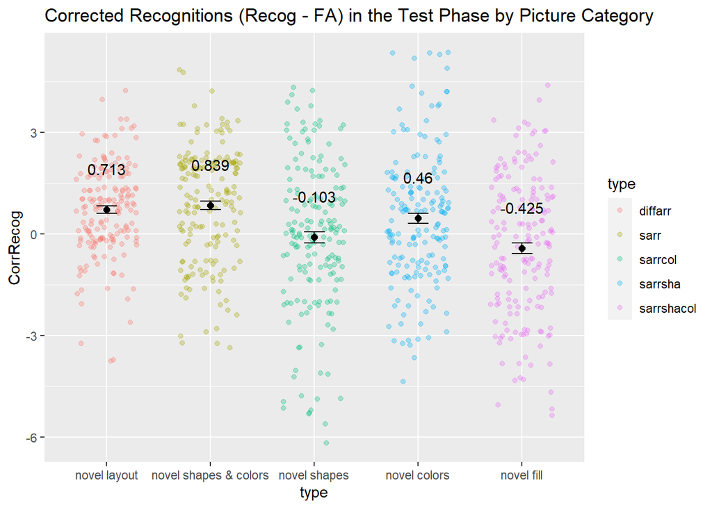

ANOVA (factor: TYPE (5 levels)): (F[3.6979017,318.0195471] = 7.5997043, p = 1.402947710^{-5}, n2G = 0.0636312).

```
## [1] "ANOVA with correct rejection minus false alarm by category"
```

```
## Anova Table (Type 3 tests)
##
## Response: CorrRejec
##   Effect           df  MSE        F  ges p.value
## 1   type 3.87, 332.61 3.75 8.13 *** .067   <.001
## ---
## Signif. codes:  0 '***' 0.001 '**' 0.01 '*' 0.05 '+' 0.1 ' ' 1
##
## Sphericity correction method: GG
```

```
##  contrast             estimate    SE  df t.ratio p.value
##  diffarr - sarr          0.322 0.289 344 1.114   0.7990
##  diffarr - sarrcol       0.885 0.289 344 3.064   0.0198
##  diffarr - sarrsha       0.989 0.289 344 3.422   0.0062
##  diffarr - sarrshacol    1.483 0.289 344 5.134   <.0001
##  sarr - sarrcol          0.563 0.289 344 1.950   0.2931
##  sarr - sarrsha          0.667 0.289 344 2.308   0.1447
##  sarr - sarrshacol       1.161 0.289 344 4.019   0.0007
##  sarrcol - sarrsha       0.103 0.289 344 0.358   0.9965
##  sarrcol - sarrshacol    0.598 0.289 344 2.069   0.2358
##  sarrsha - sarrshacol    0.494 0.289 344 1.711   0.4284
##
## P value adjustment: tukey method for comparing a family of 5 estimates
```

```
##  contrast  estimate    SE  df t.ratio p.value
##  linear      -3.632 0.646 344 -5.624  <.0001
##  quadratic    0.115 0.764 344  0.150  0.8805
##  cubic       -0.149 0.646 344 -0.231  0.8172
##  quartic     -1.552 1.709 344 -0.908  0.3645
```

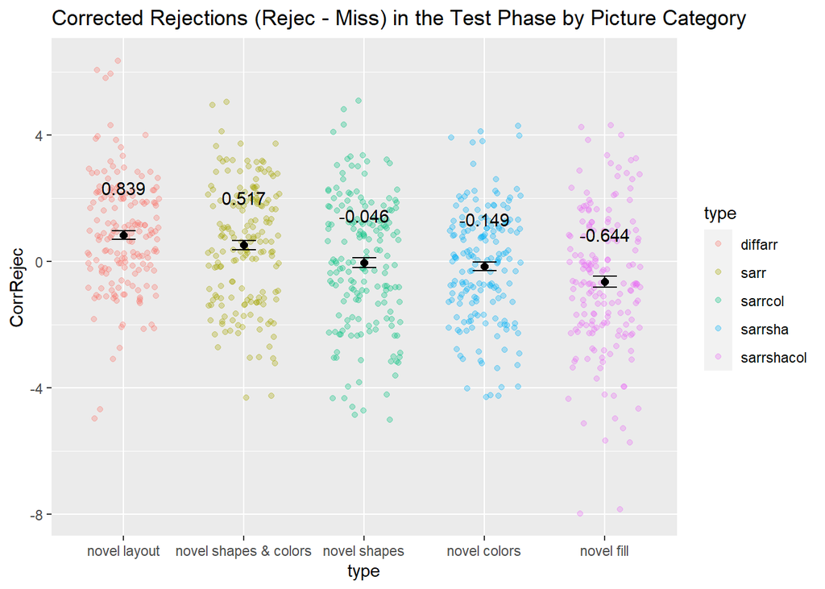

ANOVA (factor: TYPE (5 levels)): (F[3.8675874,332.6125205] = 8.1322716, p = 3.922648710^{-6}, n2G = 0.0669823).

```
## [1] "ANOVA with Overall Corrected Categorizations ((Recog-FA)+(Reject-Miss))"
```

```
## Anova Table (Type 3 tests)
##
## Response: OverallCCat
##   Effect           df   MSE        F  ges p.value
## 1   type 3.88, 333.94 12.00 8.79 *** .072   <.001
## ---
## Signif. codes:  0 '***' 0.001 '**' 0.01 '*' 0.05 '+' 0.1 ' ' 1
##
## Sphericity correction method: GG
```

```
##  contrast             estimate    SE  df t.ratio p.value
##  diffarr - sarr          0.195 0.518 344  0.378  0.9957
##  diffarr - sarrcol       1.701 0.518 344  3.287  0.0098
##  diffarr - sarrsha       1.241 0.518 344  2.399  0.1181
##  diffarr - sarrshacol    2.621 0.518 344  5.064  <.0001
##  sarr - sarrcol          1.506 0.518 344  2.909  0.0314
##  sarr - sarrsha          1.046 0.518 344  2.021  0.2581
##  sarr - sarrshacol       2.425 0.518 344  4.686  <.0001
##  sarrcol - sarrsha      -0.460 0.518 344 -0.888  0.9011
##  sarrcol - sarrshacol    0.920 0.518 344  1.777  0.3888
##  sarrsha - sarrshacol    1.379 0.518 344  2.665  0.0614
##
## P value adjustment: tukey method for comparing a family of 5 estimates
```

```
##  contrast  estimate   SE  df t.ratio p.value
##  linear      -6.287 1.16 344 -5.433  <.0001
##  quadratic   -0.402 1.37 344 -0.294  0.7691
##  cubic       -0.529 1.16 344 -0.457  0.6480
##  quartic     -7.080 3.06 344 -2.313  0.0213
```

[figure not shown]

ANOVA (factor: TYPE (5 levels)): (F[3.8830464,333.9419872] = 8.7903447, p = 1.255744110^{-6}, n2G = 0.0719164).

# Mixed models

## The metrics

### DTF - Difference To corresponding Familiar picture

All pictures are compared to a familiar. The number of differences between the three vectors of the pictures yields a difference score.

### DTAF - mean Difference To All Familiars

We calculate the difference from all prototypes and take the mean for each picture in the set.

### DTAN - mean Difference To All other Novels in the same category

We calculate the differences between each pair of pictures and then take the mean of these differences (19 comparisons per stim).

### DTN_byPhase - mean Difference to Novels in the same category per study/test phase

We calculate the differences between each pair of pictures and then take the mean of these differences (9 comparisons per stim).

### DTPPm - mean Diff To Previously seen Pictures

We compare the current picture to all previously seen pictures (25 in first study trial, 26 in 2nd, and so on ..). We take the mean.

## Study phase

With these models i tried to assess which difference index explains familiar v novel distinction in study phase the best. As far as i understand, the model with the smallest AIC fits best to our data, which means that the mean difference from the corresponding familiar worked best here. The models all show, that the more different pictures are categorized with the highest efficacy.

```
## Generalized linear mixed model fit by maximum likelihood (Laplace
##   Approximation) [glmerMod]
##  Family: binomial  ( logit )
## Formula: st_corr ~ factor(type) + (1 | workerId)
##    Data: stlmm
##
##      AIC      BIC   logLik deviance df.resid
##   7264.5   7312.0  -3625.3   7250.5     6518
##
## Scaled residuals:
##     Min      1Q  Median      3Q     Max
## -4.1880 -0.9959  0.4867  0.6252  1.5433
##
## Random effects:
##  Groups   Name        Variance Std.Dev.
##  workerId (Intercept) 0.2985   0.5463
## Number of obs: 6525, groups:  workerId, 87
##
## Fixed effects:
##                        Estimate Std. Error z value Pr(>|z|)
## (Intercept)              1.8494     0.1138  16.248  < 2e-16 ***
## factor(type)prototype   -0.8616     0.1086  -7.934 2.12e-15 ***
## factor(type)sarr        -0.7838     0.1247  -6.285 3.27e-10 ***
## factor(type)sarrcol     -0.7338     0.1252  -5.860 4.62e-09 ***
## factor(type)sarrsha     -1.3017     0.1211 -10.752  < 2e-16 ***
## factor(type)sarrshacol  -0.6503     0.1261  -5.155 2.54e-07 ***
## ---
## Signif. codes:  0 '***' 0.001 '**' 0.01 '*' 0.05 '.' 0.1 ' ' 1
##
## Correlation of Fixed Effects:
##                 (Intr) fctr(typ)p factr(typ)srr fctr(typ)srrc factr(typ)srrsh
## fctr(typ)pr     -0.764
## factr(typ)srr   -0.665  0.695
## fctr(typ)srrc   -0.662  0.692      0.602
## factr(typ)srrsh -0.687  0.717      0.624         0.621
## fctr(typ)srrshc -0.656  0.686      0.598         0.595         0.616
```

```
## Package `effects` is not available, but needed for `ggeffect()`. Either install package `effects`, or use `ggpredict()`. Calling `ggpredict()` now.FALSE
```

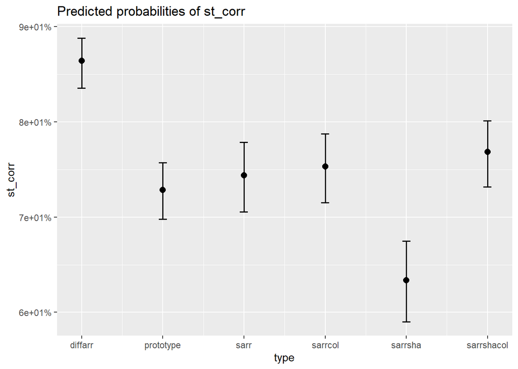

```
## Generalized linear mixed model fit by maximum likelihood (Laplace
##   Approximation) [glmerMod]
##  Family: binomial  ( logit )
## Formula: st_corr ~ DTF + (1 | workerId)
##    Data: stlmm
##
##      AIC      BIC   logLik deviance df.resid
##   7312.2   7332.6  -3653.1   7306.2     6522
##
## Scaled residuals:
##     Min      1Q  Median      3Q     Max
## -3.3346 -1.1070  0.4989  0.6177  1.3065
##
## Random effects:
##  Groups   Name        Variance Std.Dev.
##  workerId (Intercept) 0.2925   0.5408
## Number of obs: 6525, groups:  workerId, 87
##
## Fixed effects:
##             Estimate Std. Error z value Pr(>|z|)
## (Intercept)  0.86392    0.06910  12.502   <2e-16 ***
## DTF          0.04920    0.00592   8.309   <2e-16 ***
## ---
## Signif. codes:  0 '***' 0.001 '**' 0.01 '*' 0.05 '.' 0.1 ' ' 1
##
## Correlation of Fixed Effects:
##     (Intr)
## DTF -0.331
```

```
## Package `effects` is not available, but needed for `ggeffect()`. Either install package `effects`, or use `ggpredict()`. Calling `ggpredict()` now.FALSE
```

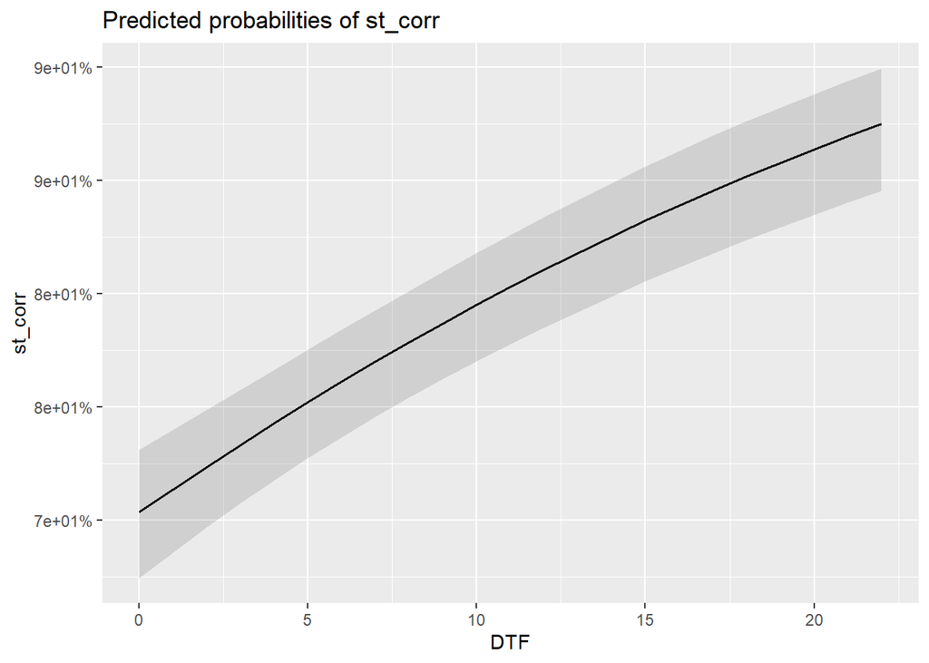

```
## Generalized linear mixed model fit by maximum likelihood (Laplace
##   Approximation) [glmerMod]
##  Family: binomial  ( logit )
## Formula: st_corr ~ DTAF + (1 | workerId)
##    Data: stlmm
##
##      AIC      BIC   logLik deviance df.resid
##   7357.6   7377.9  -3675.8   7351.6     6522
##
## Scaled residuals:
##     Min      1Q  Median      3Q     Max
## -3.2009 -1.1145  0.4977  0.6150  1.2931
##
## Random effects:
##  Groups   Name        Variance Std.Dev.
##  workerId (Intercept) 0.2881   0.5368
## Number of obs: 6525, groups:  workerId, 87
##
## Fixed effects:
##             Estimate Std. Error z value Pr(>|z|)
## (Intercept) 0.870676   0.073890  11.783  < 2e-16 ***
## DTAF        0.023976   0.004378   5.476 4.35e-08 ***
## ---
## Signif. codes:  0 '***' 0.001 '**' 0.01 '*' 0.05 '.' 0.1 ' ' 1
##
## Correlation of Fixed Effects:
##      (Intr)
## DTAF -0.481
```

```
## Package `effects` is not available, but needed for `ggeffect()`. Either install package `effects`, or use `ggpredict()`. Calling `ggpredict()` now.FALSE
```

```
## Data were 'prettified'. Consider using `terms="DTAF [all]"` to get smooth plots.
```

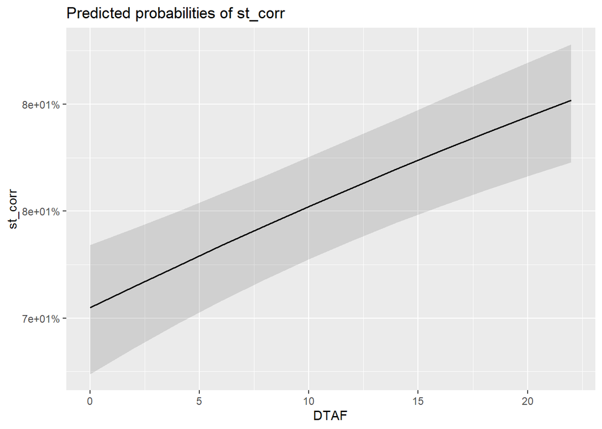

```
## Generalized linear mixed model fit by maximum likelihood (Laplace
##   Approximation) [glmerMod]
##  Family: binomial  ( logit )
## Formula: st_corr ~ DTAN + (1 | workerId)
##    Data: stlmm
##
##      AIC      BIC   logLik deviance df.resid
##   7368.5   7388.8  -3681.2   7362.5     6522
##
## Scaled residuals:
##     Min      1Q  Median      3Q     Max
## -3.1889 -1.1243  0.4999  0.6183  1.2693
##
## Random effects:
##  Groups   Name        Variance Std.Dev.
##  workerId (Intercept) 0.287    0.5357
## Number of obs: 6525, groups:  workerId, 87
##
## Fixed effects:
##             Estimate Std. Error z value Pr(>|z|)
## (Intercept) 0.904646   0.074598  12.127  < 2e-16 ***
## DTAN        0.019927   0.004553   4.377 1.21e-05 ***
## ---
## Signif. codes:  0 '***' 0.001 '**' 0.01 '*' 0.05 '.' 0.1 ' ' 1
##
## Correlation of Fixed Effects:
##      (Intr)
## DTAN -0.499
```

```
## Package `effects` is not available, but needed for `ggeffect()`. Either install package `effects`, or use `ggpredict()`. Calling `ggpredict()` now.FALSE
```

```
## Data were 'prettified'. Consider using `terms="DTAN [all]"` to get smooth plots.
```

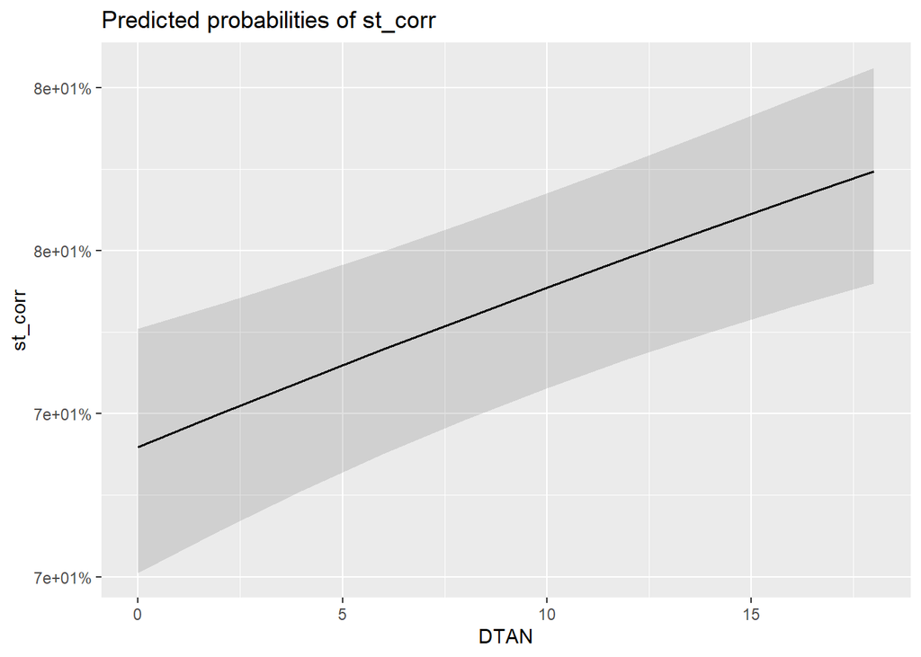

```
## Generalized linear mixed model fit by maximum likelihood (Laplace
##   Approximation) [glmerMod]
##  Family: binomial  ( logit )
## Formula: st_corr ~ DTN_byPhase + (1 | workerId)
##    Data: stlmm
##
##      AIC      BIC   logLik deviance df.resid
##   7368.4   7388.8  -3681.2   7362.4     6522
##
## Scaled residuals:
##     Min      1Q  Median      3Q     Max
## -3.1880 -1.1261  0.4999  0.6179  1.2697
##
## Random effects:
##  Groups   Name        Variance Std.Dev.
##  workerId (Intercept) 0.287    0.5357
## Number of obs: 6525, groups:  workerId, 87
##
## Fixed effects:
##             Estimate Std. Error z value Pr(>|z|)
## (Intercept) 0.904031   0.074636  12.113  < 2e-16 ***
## DTN_byPhase 0.019319   0.004406   4.385 1.16e-05 ***
## ---
## Signif. codes:  0 '***' 0.001 '**' 0.01 '*' 0.05 '.' 0.1 ' ' 1
##
## Correlation of Fixed Effects:
##             (Intr)
## DTN_byPhase -0.499
```

```
## Package `effects` is not available, but needed for `ggeffect()`. Either install package `effects`, or use `ggpredict()`. Calling `ggpredict()` now.FALSE
```

```
## Data were 'prettified'. Consider using `terms="DTN_byPhase [all]"` to get smooth plots.
```

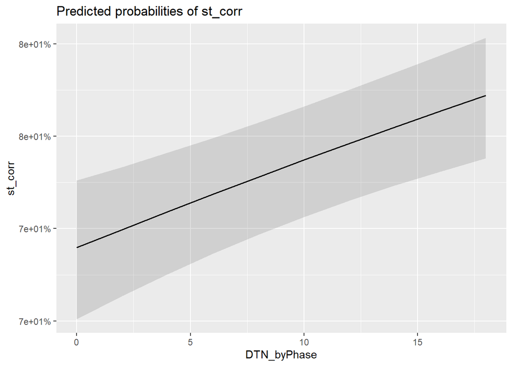

|  | st_corr |  |  |  | st_corr |  |  |  | st_corr |  |  |  | st_corr |  |  |  | st_corr |  |  |  |
| --- | --- | --- | --- | --- | --- | --- | --- | --- | --- | --- | --- | --- | --- | --- | --- | --- | --- | --- | --- | --- |
| Predictors | Log-Odds | std. Error | CI | p | Log-Odds | std. Error | CI | p | Log-Odds | std. Error | CI | p | Log-Odds | std. Error | CI | p | Log-Odds | std. Error | CI | p |
| (Intercept) | 1.85 | 0.11 | 1.63 – 2.07 | **<0.001** | 0.86 | 0.07 | 0.73 – 1.00 | **<0.001** | 0.87 | 0.07 | 0.73 – 1.02 | **<0.001** | 0.90 | 0.07 | 0.76 – 1.05 | **<0.001** | 0.90 | 0.07 | 0.76 – 1.05 | **<0.001** |
| type [prototype] | -0.86 | 0.11 | -1.07 – -0.65 | **<0.001** |  |  |  |  |  |  |  |  |  |  |  |  |  |  |  |  |
| type [sarr] | -0.78 | 0.12 | -1.03 – -0.54 | **<0.001** |  |  |  |  |  |  |  |  |  |  |  |  |  |  |  |  |
| type [sarrcol] | -0.73 | 0.13 | -0.98 – -0.49 | **<0.001** |  |  |  |  |  |  |  |  |  |  |  |  |  |  |  |  |
| type [sarrsha] | -1.30 | 0.12 | -1.54 – -1.06 | **<0.001** |  |  |  |  |  |  |  |  |  |  |  |  |  |  |  |  |
| type [sarrshacol] | -0.65 | 0.13 | -0.90 – -0.40 | **<0.001** |  |  |  |  |  |  |  |  |  |  |  |  |  |  |  |  |
| DTF |  |  |  |  | 0.05 | 0.01 | 0.04 – 0.06 | **<0.001** |  |  |  |  |  |  |  |  |  |  |  |  |
| DTAF |  |  |  |  |  |  |  |  | 0.02 | 0.00 | 0.02 – 0.03 | **<0.001** |  |  |  |  |  |  |  |  |
| DTAN |  |  |  |  |  |  |  |  |  |  |  |  | 0.02 | 0.00 | 0.01 – 0.03 | **<0.001** |  |  |  |  |
| DTN_byPhase |  |  |  |  |  |  |  |  |  |  |  |  |  |  |  |  | 0.02 | 0.00 | 0.01 – 0.03 | **<0.001** |
| Random Effects |  |  |  |  |  |  |  |  |  |  |  |  |  |  |  |  |  |  |  |  |
| σ<sup>2</sup> | 3.29 |  |  |  | 3.29 |  |  |  | 3.29 |  |  |  | 3.29 |  |  |  | 3.29 |  |  |  |
| τ<sub>00</sub> | 0.30 <sub>workerId</sub> |  |  |  | 0.29 <sub>workerId</sub> |  |  |  | 0.29 <sub>workerId</sub> |  |  |  | 0.29 <sub>workerId</sub> |  |  |  | 0.29 <sub>workerId</sub> |  |  |  |
| ICC | 0.08 |  |  |  | 0.08 |  |  |  | 0.08 |  |  |  | 0.08 |  |  |  | 0.08 |  |  |  |
| N | 87 <sub>workerId</sub> |  |  |  | 87 <sub>workerId</sub> |  |  |  | 87 <sub>workerId</sub> |  |  |  | 87 <sub>workerId</sub> |  |  |  | 87 <sub>workerId</sub> |  |  |  |
| Observations | 6525 |  |  |  | 6525 |  |  |  | 6525 |  |  |  | 6525 |  |  |  | 6525 |  |  |  |
| Marginal R<sup>2</sup> / Conditional R<sup>2</sup> | 0.033 / 0.113 |  |  |  | 0.020 / 0.100 |  |  |  | 0.007 / 0.087 |  |  |  | 0.004 / 0.084 |  |  |  | 0.004 / 0.084 |  |  |  |
| AIC | 7264.534 |  |  |  | 7312.217 |  |  |  | 7357.586 |  |  |  | 7368.482 |  |  |  | 7368.415 |  |  |  |

## Test phase

### Models #1

Logistic mixed regression for the test phase. Does difference from prototypes or familiarity/novelty have an effect on correct categorization in the test phase?

These models use trial quality (familiar / novel) as a fixed and as a random effect.

rt_resp is recognition test response, 0 stands for ‘old’ and 1 stands for ‘new’.

```
## Generalized linear mixed model fit by maximum likelihood (Laplace
##   Approximation) [glmerMod]
##  Family: binomial  ( logit )
## Formula: rt_resp ~ type * tq + (tq | workerId)
##    Data: tdlmm
##
##      AIC      BIC   logLik deviance df.resid
##   8612.8   8702.2  -4293.4   8586.8     7151
##
## Scaled residuals:
##     Min      1Q  Median      3Q     Max
## -5.4109 -0.8965  0.4211  0.7574  3.9823
##
## Random effects:
##  Groups   Name        Variance Std.Dev. Corr
##  workerId (Intercept) 0.6610   0.8130
##           tqold       0.0287   0.1694   -0.88
## Number of obs: 7164, groups:  workerId, 87
##
## Fixed effects:
##                      Estimate Std. Error z value Pr(>|z|)
## (Intercept)            1.8479     0.1381  13.382  < 2e-16 ***
## typesarr              -0.7175     0.1385  -5.182 2.19e-07 ***
## typesarrcol           -1.5814     0.1327 -11.917  < 2e-16 ***
## typesarrsha           -1.8860     0.1357 -13.903  < 2e-16 ***
## typesarrshacol        -2.0997     0.1348 -15.576  < 2e-16 ***
## tqold                 -0.6527     0.1406  -4.642 3.45e-06 ***
## typesarr:tqold         0.1709     0.1830   0.934 0.350530
## typesarrcol:tqold      0.6823     0.1779   3.836 0.000125 ***
## typesarrsha:tqold      0.5618     0.1806   3.112 0.001860 **
## typesarrshacol:tqold   0.9404     0.1797   5.232 1.67e-07 ***
## ---
## Signif. codes:  0 '***' 0.001 '**' 0.01 '*' 0.05 '.' 0.1 ' ' 1
##
## Correlation of Fixed Effects:
##             (Intr) typesrr typsrrc typesrrsh typsrrshc tqold  typsrr:t typsrrc:
## typesarr    -0.585
## typesarrcol -0.622  0.609
## typesarrsha -0.611  0.597   0.634
## typesrrshcl -0.617  0.601   0.639   0.629
## tqold       -0.662  0.575   0.611   0.600     0.607
## typsrr:tqld  0.442 -0.756  -0.460  -0.451    -0.454    -0.742
## typsrrcl:tq  0.464 -0.454  -0.746  -0.472    -0.477    -0.774  0.586
## typsrrsh:tq  0.459 -0.448  -0.476  -0.751    -0.472    -0.766  0.578    0.603
## typsrrshcl:  0.463 -0.450  -0.479  -0.471    -0.750    -0.771  0.581    0.607
##             typsrrsh:t
## typesarr
## typesarrcol
## typesarrsha
## typesrrshcl
## tqold
## typsrr:tqld
## typsrrcl:tq
## typsrrsh:tq
## typsrrshcl:  0.601
## convergence code: 0
## Model failed to converge with max|grad| = 0.0253398 (tol = 0.002, component 1)
```

```
## Package `effects` is not available, but needed for `ggeffect()`. Either install package `effects`, or use `ggpredict()`. Calling `ggpredict()` now.FALSE
```

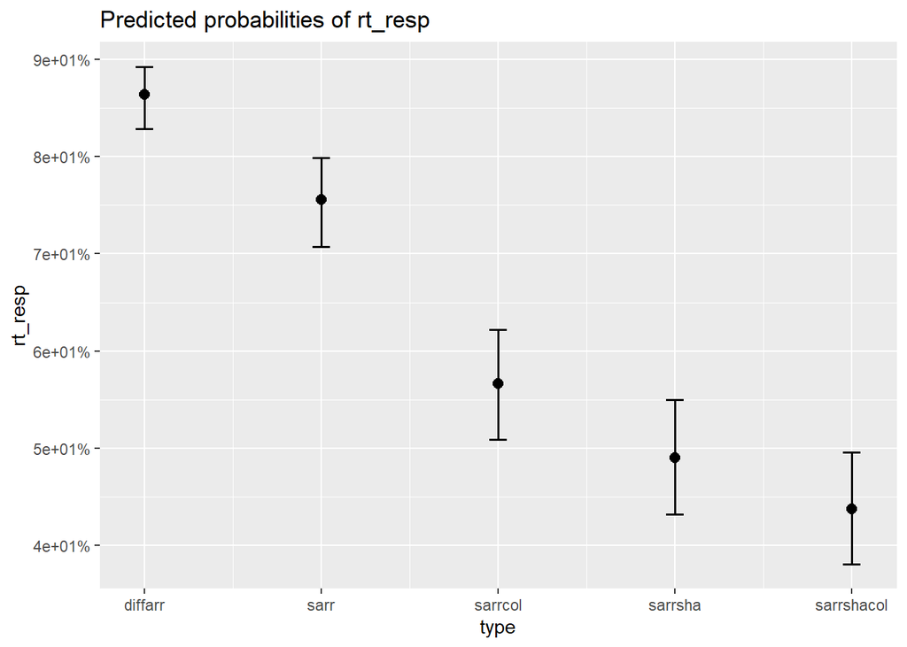

```
## Package `effects` is not available, but needed for `ggeffect()`. Either install package `effects`, or use `ggpredict()`. Calling `ggpredict()` now.FALSE
```

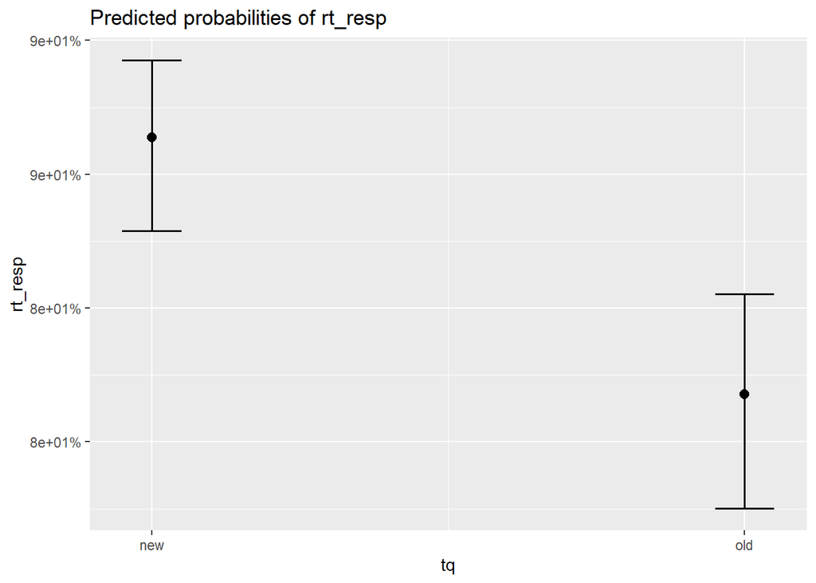

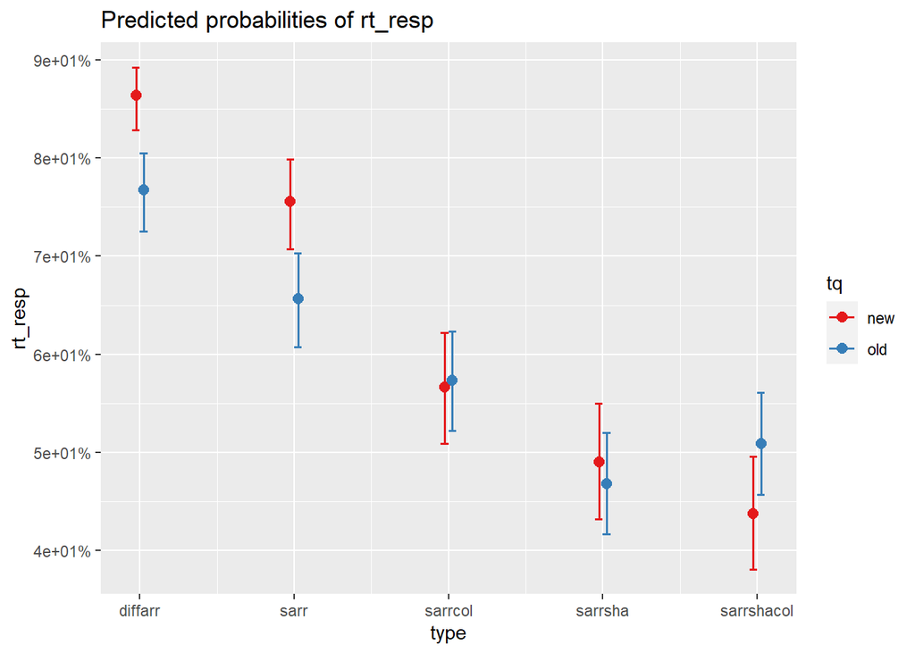

```
## Generalized linear mixed model fit by maximum likelihood (Laplace
##   Approximation) [glmerMod]
##  Family: binomial  ( logit )
## Formula: rt_resp ~ DTF * tq + (tq | workerId)
##    Data: tdlmm
##
##      AIC      BIC   logLik deviance df.resid
##   8710.2   8758.3  -4348.1   8696.2     7157
##
## Scaled residuals:
##     Min      1Q  Median      3Q     Max
## -5.1009 -0.9265  0.4376  0.7827  4.7574
##
## Random effects:
##  Groups   Name        Variance Std.Dev. Corr
##  workerId (Intercept) 0.63153  0.7947
##           tqold       0.02333  0.1527   -0.89
## Number of obs: 7164, groups:  workerId, 87
##
## Fixed effects:
##              Estimate Std. Error z value Pr(>|z|)
## (Intercept) -0.394243   0.107943  -3.652  0.00026 ***
## DTF          0.139881   0.009035  15.482  < 2e-16 ***
## tqold        0.246867   0.089719   2.752  0.00593 **
## DTF:tqold   -0.058234   0.011673  -4.989 6.07e-07 ***
## ---
## Signif. codes:  0 '***' 0.001 '**' 0.01 '*' 0.05 '.' 0.1 ' ' 1
##
## Correlation of Fixed Effects:
##           (Intr) DTF    tqold
## DTF       -0.497
## tqold     -0.577  0.596
## DTF:tqold  0.384 -0.774 -0.788
```

```
## Package `effects` is not available, but needed for `ggeffect()`. Either install package `effects`, or use `ggpredict()`. Calling `ggpredict()` now.FALSE
```

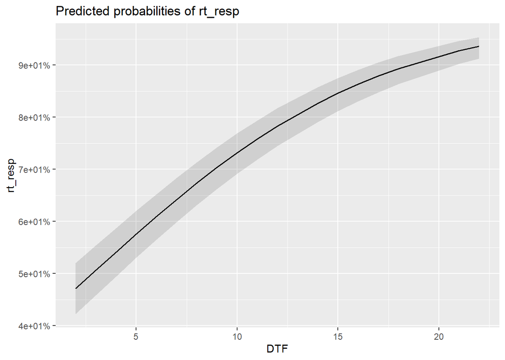

```
## Package `effects` is not available, but needed for `ggeffect()`. Either install package `effects`, or use `ggpredict()`. Calling `ggpredict()` now.FALSE
```

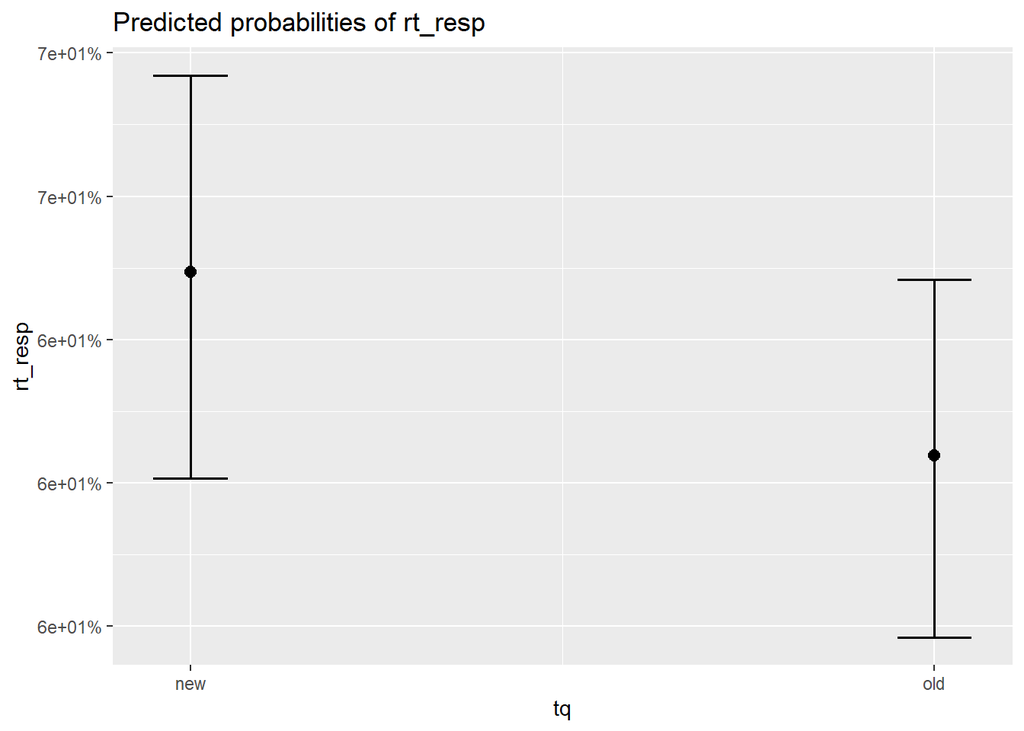

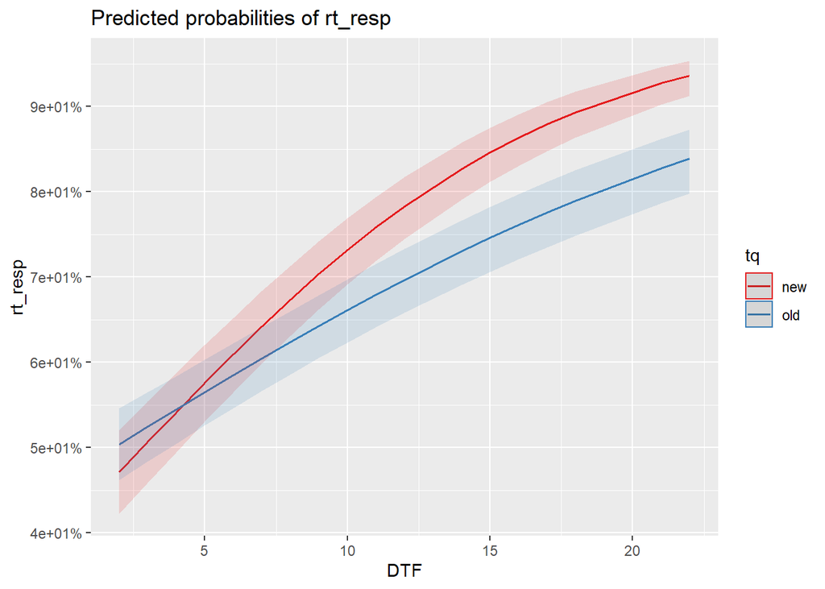

```
## Generalized linear mixed model fit by maximum likelihood (Laplace
##   Approximation) [glmerMod]
##  Family: binomial  ( logit )
## Formula: rt_resp ~ DTAF * tq + (tq | workerId)
##    Data: tdlmm
##
##      AIC      BIC   logLik deviance df.resid
##   8718.7   8766.8  -4352.3   8704.7     7157
##
## Scaled residuals:
##     Min      1Q  Median      3Q     Max
## -5.1168 -0.9248  0.4444  0.7782  3.9594
##
## Random effects:
##  Groups   Name        Variance Std.Dev. Corr
##  workerId (Intercept) 0.61346  0.7832
##           tqold       0.01645  0.1282   -0.96
## Number of obs: 7164, groups:  workerId, 87
##
## Fixed effects:
##             Estimate Std. Error z value Pr(>|z|)
## (Intercept) -2.50923    0.21462 -11.691  < 2e-16 ***
## DTAF         0.23709    0.01552  15.278  < 2e-16 ***
## tqold        0.87636    0.26437   3.315 0.000917 ***
## DTAF:tqold  -0.07868    0.02066  -3.809 0.000139 ***
## ---
## Signif. codes:  0 '***' 0.001 '**' 0.01 '*' 0.05 '.' 0.1 ' ' 1
##
## Correlation of Fixed Effects:
##            (Intr) DTAF   tqold
## DTAF       -0.902
## tqold      -0.706  0.732
## DTAF:tqold  0.678 -0.751 -0.979
```

[output not shown]

[output not shown]

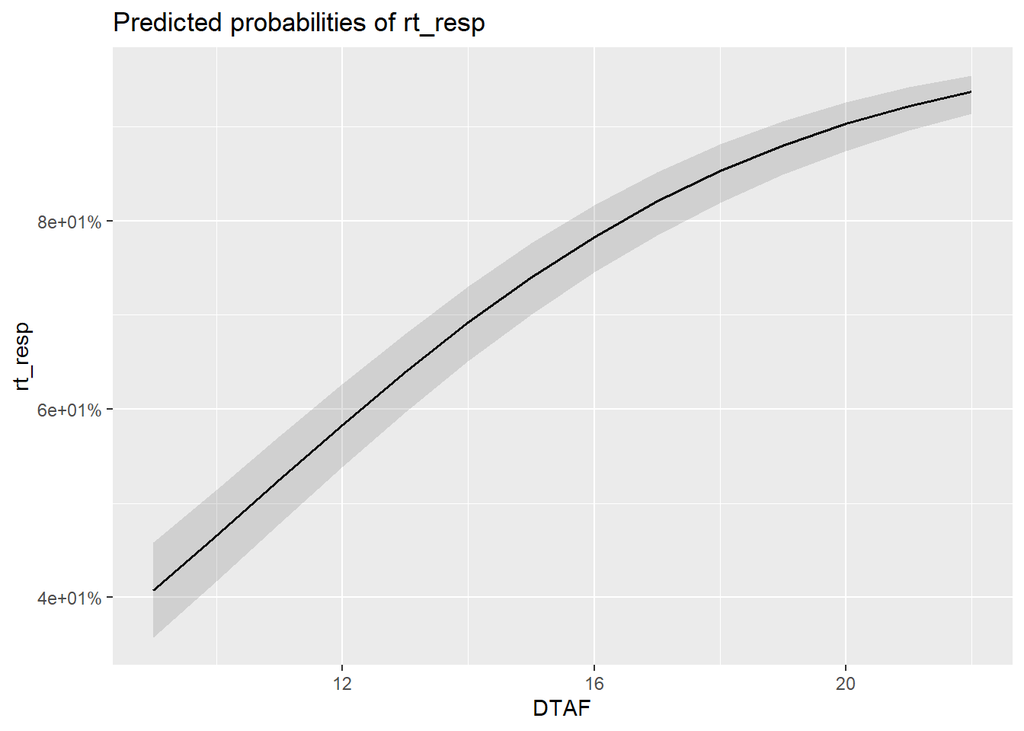

[output not shown]

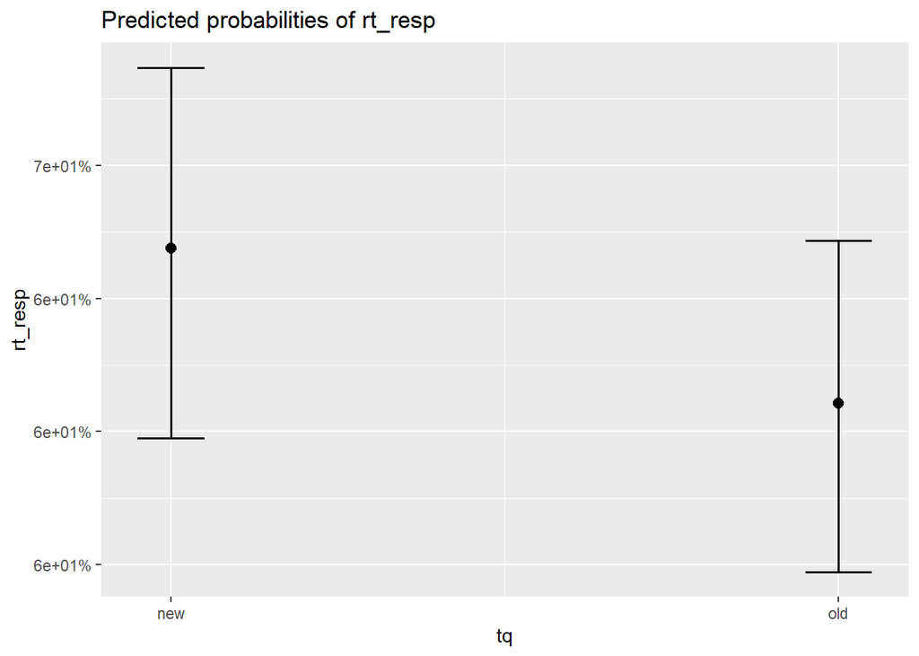

[output not shown]

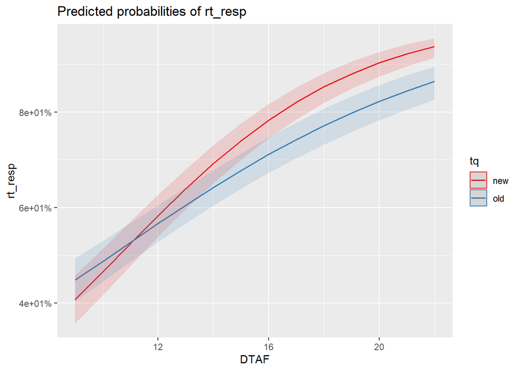

```
## Generalized linear mixed model fit by maximum likelihood (Laplace
##   Approximation) [glmerMod]
##  Family: binomial  ( logit )
## Formula: rt_resp ~ DTAN * tq + (tq | workerId)
##    Data: tdlmm
##
##      AIC      BIC   logLik deviance df.resid
##   8768.6   8816.7  -4377.3   8754.6     7157
##
## Scaled residuals:
##     Min      1Q  Median      3Q     Max
## -6.1453 -0.9321  0.4707  0.7662  3.4815
##
## Random effects:
##  Groups   Name        Variance Std.Dev. Corr
##  workerId (Intercept) 0.59730  0.7729
##           tqold       0.01264  0.1124   -0.97
## Number of obs: 7164, groups:  workerId, 87
##
## Fixed effects:
##             Estimate Std. Error z value Pr(>|z|)
## (Intercept) -3.57695    0.28882 -12.385  < 2e-16 ***
## DTAN         0.32338    0.02184  14.803  < 2e-16 ***
## tqold        1.02448    0.37738   2.715  0.00663 **
## DTAN:tqold  -0.09231    0.02966  -3.112  0.00186 **
## ---
## Signif. codes:  0 '***' 0.001 '**' 0.01 '*' 0.05 '.' 0.1 ' ' 1
##
## Correlation of Fixed Effects:
##            (Intr) DTAN   tqold
## DTAN       -0.949
## tqold      -0.711  0.726
## DTAN:tqold  0.699 -0.737 -0.990
```

[output not shown]

[output not shown]

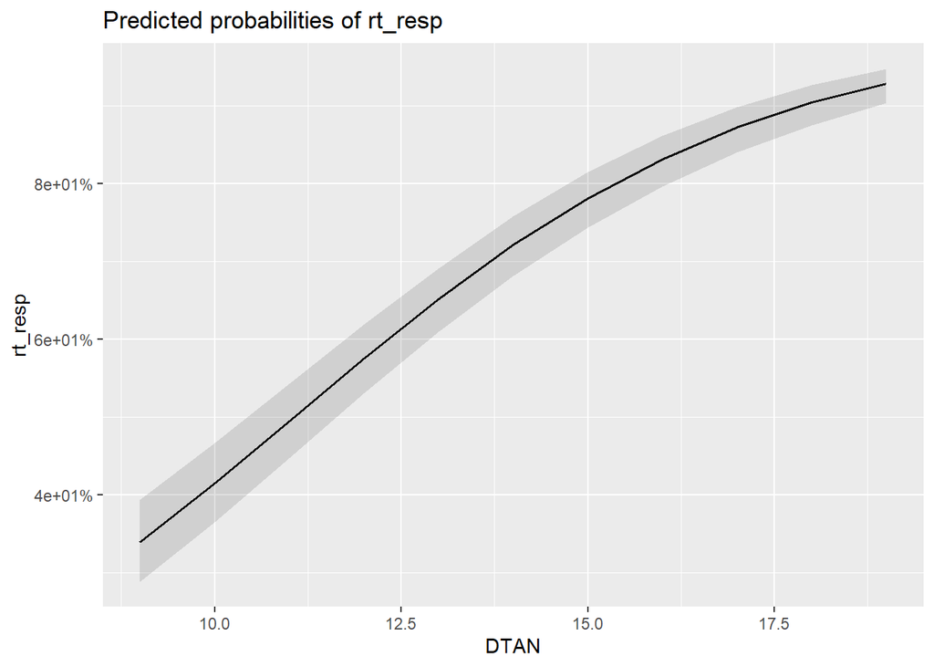

[output not shown]

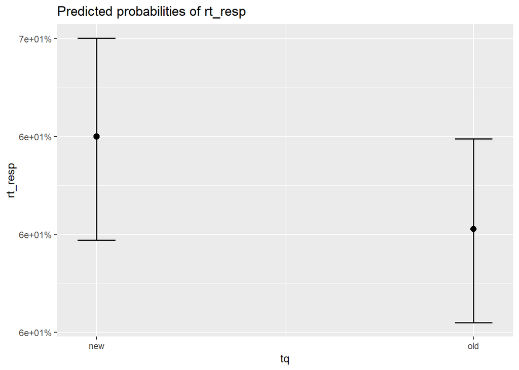

[output not shown]

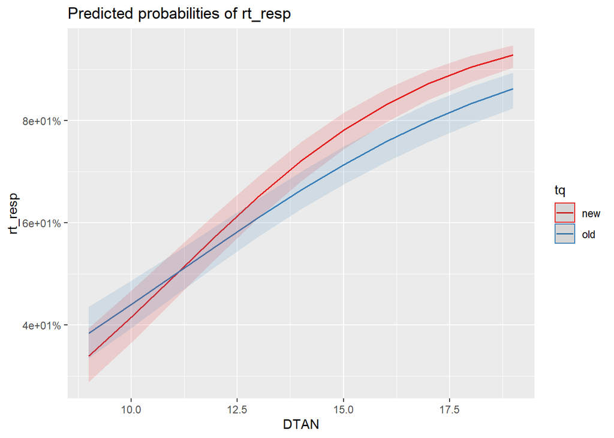

```
## Generalized linear mixed model fit by maximum likelihood (Laplace
##   Approximation) [glmerMod]
##  Family: binomial  ( logit )
## Formula: rt_resp ~ DTN_byPhase * tq + (tq | workerId)
##    Data: tdlmm
##
##      AIC      BIC   logLik deviance df.resid
##   8803.5   8851.7  -4394.8   8789.5     7157
##
## Scaled residuals:
##     Min      1Q  Median      3Q     Max
## -5.4719 -0.9370  0.4770  0.7692  3.4357
##
## Random effects:
##  Groups   Name        Variance Std.Dev. Corr
##  workerId (Intercept) 0.58979  0.768
##           tqold       0.01123  0.106    -1.00
## Number of obs: 7164, groups:  workerId, 87
##
## Fixed effects:
##                   Estimate Std. Error z value Pr(>|z|)
## (Intercept)       -3.45474    0.29132 -11.859  < 2e-16 ***
## DTN_byPhase        0.30236    0.02124  14.236  < 2e-16 ***
## tqold              0.94192    0.38407   2.452  0.01419 *
## DTN_byPhase:tqold -0.08228    0.02910  -2.828  0.00469 **
## ---
## Signif. codes:  0 '***' 0.001 '**' 0.01 '*' 0.05 '.' 0.1 ' ' 1
##
## Correlation of Fixed Effects:
##             (Intr) DTN_bP tqold
## DTN_byPhase -0.950
## tqold       -0.706  0.721
## DTN_byPhs:t  0.694 -0.730 -0.990
```

[output not shown]

[output not shown]

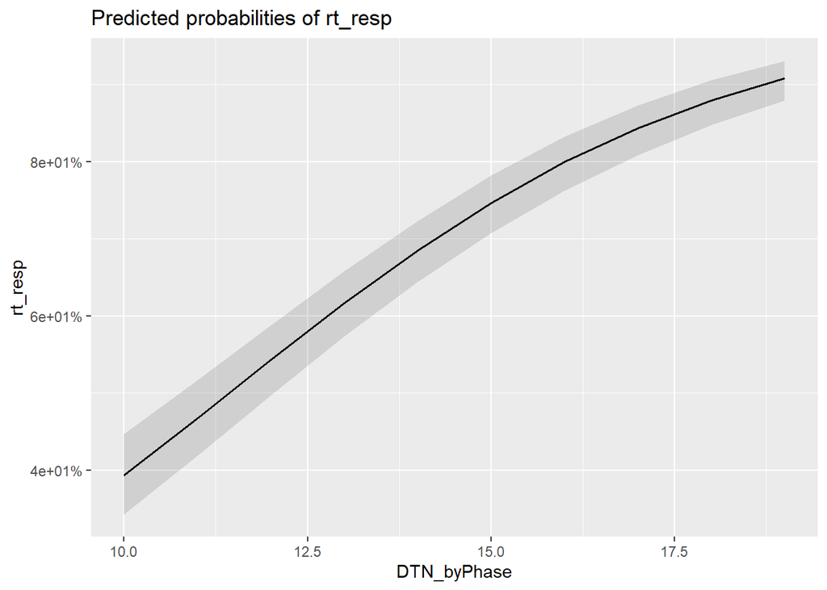

[output not shown]

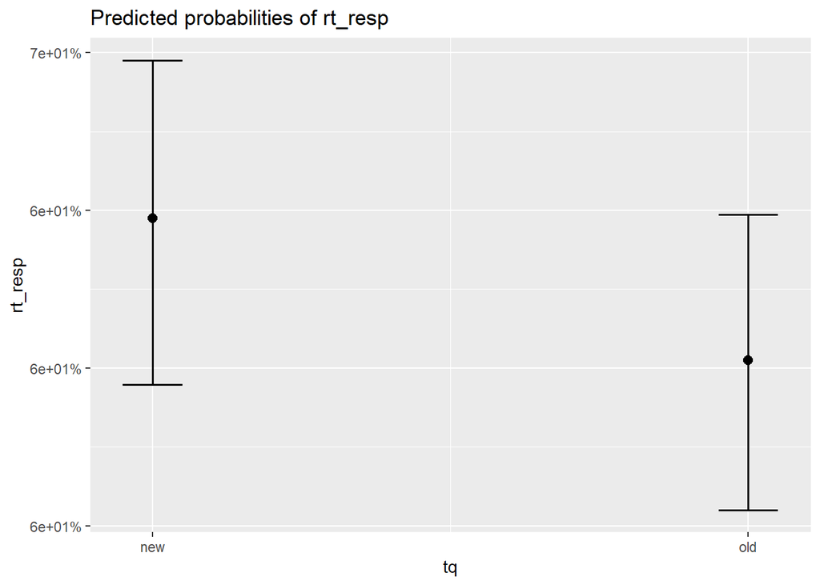

[output not shown]

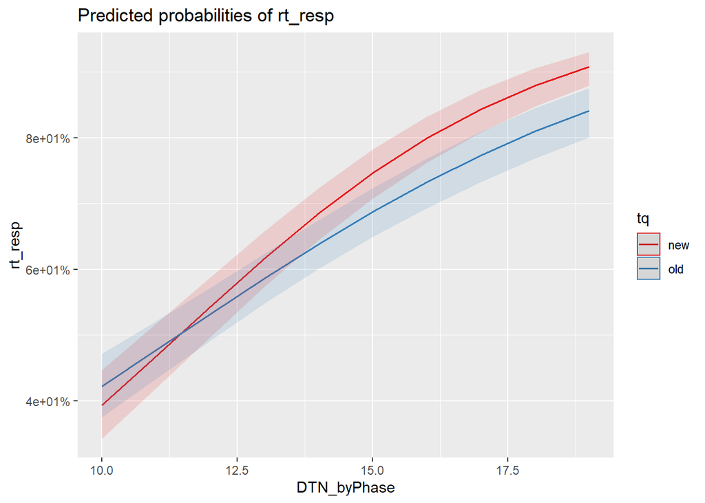

|  | rt_resp |  |  |  | rt_resp |  |  |  | rt_resp |  |  |  | rt_resp |  |  |  | rt_resp |  |  |  |
| --- | --- | --- | --- | --- | --- | --- | --- | --- | --- | --- | --- | --- | --- | --- | --- | --- | --- | --- | --- | --- |
| Predictors | Log-Odds | std. Error | CI | p | Log-Odds | std. Error | CI | p | Log-Odds | std. Error | CI | p | Log-Odds | std. Error | CI | p | Log-Odds | std. Error | CI | p |
| (Intercept) | 1.85 | 0.14 | 1.58 – 2.12 | **<0.001** | -0.39 | 0.11 | -0.61 – -0.18 | **<0.001** | -2.51 | 0.21 | -2.93 – -2.09 | **<0.001** | -3.58 | 0.29 | -4.14 – -3.01 | **<0.001** | -3.45 | 0.29 | -4.03 – -2.88 | **<0.001** |
| type [sarr] | -0.72 | 0.14 | -0.99 – -0.45 | **<0.001** |  |  |  |  |  |  |  |  |  |  |  |  |  |  |  |  |
| type [sarrcol] | -1.58 | 0.13 | -1.84 – -1.32 | **<0.001** |  |  |  |  |  |  |  |  |  |  |  |  |  |  |  |  |
| type [sarrsha] | -1.89 | 0.14 | -2.15 – -1.62 | **<0.001** |  |  |  |  |  |  |  |  |  |  |  |  |  |  |  |  |
| type [sarrshacol] | -2.10 | 0.13 | -2.36 – -1.84 | **<0.001** |  |  |  |  |  |  |  |  |  |  |  |  |  |  |  |  |
| tq [old] | -0.65 | 0.14 | -0.93 – -0.38 | **<0.001** | 0.25 | 0.09 | 0.07 – 0.42 | **0.006** | 0.88 | 0.26 | 0.36 – 1.39 | **0.001** | 1.02 | 0.38 | 0.28 – 1.76 | **0.007** | 0.94 | 0.38 | 0.19 – 1.69 | **0.014** |
| type [sarr] * tq [old] | 0.17 | 0.18 | -0.19 – 0.53 | 0.351 |  |  |  |  |  |  |  |  |  |  |  |  |  |  |  |  |
| type [sarrcol] * tq [old] | 0.68 | 0.18 | 0.33 – 1.03 | **<0.001** |  |  |  |  |  |  |  |  |  |  |  |  |  |  |  |  |
| type [sarrsha] * tq [old] | 0.56 | 0.18 | 0.21 – 0.92 | **0.002** |  |  |  |  |  |  |  |  |  |  |  |  |  |  |  |  |
| type [sarrshacol] * tq [old] | 0.94 | 0.18 | 0.59 – 1.29 | **<0.001** |  |  |  |  |  |  |  |  |  |  |  |  |  |  |  |  |
| DTF |  |  |  |  | 0.14 | 0.01 | 0.12 – 0.16 | **<0.001** |  |  |  |  |  |  |  |  |  |  |  |  |
| DTF * tq [old] |  |  |  |  | -0.06 | 0.01 | -0.08 – -0.04 | **<0.001** |  |  |  |  |  |  |  |  |  |  |  |  |
| DTAF |  |  |  |  |  |  |  |  | 0.24 | 0.02 | 0.21 – 0.27 | **<0.001** |  |  |  |  |  |  |  |  |
| DTAF * tq [old] |  |  |  |  |  |  |  |  | -0.08 | 0.02 | -0.12 – -0.04 | **<0.001** |  |  |  |  |  |  |  |  |
| DTAN |  |  |  |  |  |  |  |  |  |  |  |  | 0.32 | 0.02 | 0.28 – 0.37 | **<0.001** |  |  |  |  |
| DTAN * tq [old] |  |  |  |  |  |  |  |  |  |  |  |  | -0.09 | 0.03 | -0.15 – -0.03 | **0.002** |  |  |  |  |
| DTN_byPhase |  |  |  |  |  |  |  |  |  |  |  |  |  |  |  |  | 0.30 | 0.02 | 0.26 – 0.34 | **<0.001** |
| DTN_byPhase * tq [old] |  |  |  |  |  |  |  |  |  |  |  |  |  |  |  |  | -0.08 | 0.03 | -0.14 – -0.03 | **0.005** |
| Random Effects |  |  |  |  |  |  |  |  |  |  |  |  |  |  |  |  |  |  |  |  |
| σ<sup>2</sup> | 3.29 |  |  |  | 3.29 |  |  |  | 3.29 |  |  |  | 3.29 |  |  |  | 3.29 |  |  |  |
| τ<sub>00</sub> | 0.66 <sub>workerId</sub> |  |  |  | 0.63 <sub>workerId</sub> |  |  |  | 0.61 <sub>workerId</sub> |  |  |  | 0.60 <sub>workerId</sub> |  |  |  | 0.59 <sub>workerId</sub> |  |  |  |
| τ<sub>11</sub> | 0.03 <sub>workerId.tqold</sub> |  |  |  | 0.02 <sub>workerId.tqold</sub> |  |  |  | 0.02 <sub>workerId.tqold</sub> |  |  |  | 0.01 <sub>workerId.tqold</sub> |  |  |  | 0.01 <sub>workerId.tqold</sub> |  |  |  |
| ρ<sub>01</sub> | -0.88 <sub>workerId</sub> |  |  |  | -0.89 <sub>workerId</sub> |  |  |  | -0.96 <sub>workerId</sub> |  |  |  | -0.97 <sub>workerId</sub> |  |  |  | -1.00 <sub>workerId</sub> |  |  |  |
| ICC | 0.14 |  |  |  | 0.14 |  |  |  | 0.14 |  |  |  | 0.14 |  |  |  | 0.13 |  |  |  |
| N | 87 <sub>workerId</sub> |  |  |  | 87 <sub>workerId</sub> |  |  |  | 87 <sub>workerId</sub> |  |  |  | 87 <sub>workerId</sub> |  |  |  | 87 <sub>workerId</sub> |  |  |  |
| Observations | 7164 |  |  |  | 7164 |  |  |  | 7164 |  |  |  | 7164 |  |  |  | 7164 |  |  |  |
| Marginal R<sup>2</sup> / Conditional R<sup>2</sup> | 0.101 / 0.230 |  |  |  | 0.094 / 0.221 |  |  |  | 0.088 / 0.214 |  |  |  | 0.072 / 0.198 |  |  |  | 0.065 / 0.191 |  |  |  |
| AIC | 8612.886 |  |  |  | 8710.200 |  |  |  | 8718.712 |  |  |  | 8768.585 |  |  |  | 8803.551 |  |  |  |

### Models #2

Logistic mixed regression for the test phase. Does difference from prototypes or familiarity/novelty have an effect on correct categorization in the test phase?

These models use trial quality (familiar / novel) as a fixed effect only.

rt_resp is recognition test response, 0 stands for ‘old’ and 1 stands for ‘new’.

```
## Generalized linear mixed model fit by maximum likelihood (Laplace
##   Approximation) [glmerMod]
##  Family: binomial  ( logit )
## Formula: rt_resp ~ type * tq + (1 | workerId)
##    Data: tdlmm
##
##      AIC      BIC   logLik deviance df.resid
##   8613.7   8689.4  -4295.9   8591.7     7153
##
## Scaled residuals:
##     Min      1Q  Median      3Q     Max
## -4.8671 -0.8817  0.4270  0.7587  3.5425
##
## Random effects:
##  Groups   Name        Variance Std.Dev.
##  workerId (Intercept) 0.5433   0.7371
## Number of obs: 7164, groups:  workerId, 87
##
## Fixed effects:
##                      Estimate Std. Error z value Pr(>|z|)
## (Intercept)            1.8172     0.1316  13.812  < 2e-16 ***
## typesarr              -0.7093     0.1373  -5.165 2.40e-07 ***
## typesarrcol           -1.5576     0.1310 -11.888  < 2e-16 ***
## typesarrsha           -1.8584     0.1337 -13.895  < 2e-16 ***
## typesarrshacol        -2.0661     0.1327 -15.572  < 2e-16 ***
## tqold                 -0.6079     0.1377  -4.416 1.01e-05 ***
## typesarr:tqold         0.1593     0.1827   0.872 0.383337
## typesarrcol:tqold      0.6468     0.1768   3.658 0.000254 ***
## typesarrsha:tqold      0.5179     0.1790   2.893 0.003816 **
## typesarrshacol:tqold   0.8915     0.1781   5.005 5.58e-07 ***
## ---
## Signif. codes:  0 '***' 0.001 '**' 0.01 '*' 0.05 '.' 0.1 ' ' 1
##
## Correlation of Fixed Effects:
##             (Intr) typesrr typsrrc typesrrsh typsrrshc tqold  typsrr:t typsrrc:
## typesarr    -0.607
## typesarrcol -0.640  0.609
## typesarrsha -0.628  0.598   0.631
## typesrrshcl -0.634  0.603   0.637   0.625
## tqold       -0.606  0.579   0.609   0.597     0.602
## typsrr:tqld  0.455 -0.751  -0.457  -0.448    -0.452    -0.753
## typsrrcl:tq  0.472 -0.451  -0.739  -0.465    -0.469    -0.779  0.586
## typsrrsh:tq  0.466 -0.446  -0.468  -0.743    -0.463    -0.769  0.579    0.599
## typsrrshcl:  0.469 -0.448  -0.471  -0.462    -0.741    -0.773  0.582    0.602
##             typsrrsh:t
## typesarr
## typesarrcol
## typesarrsha
## typesrrshcl
## tqold
## typsrr:tqld
## typsrrcl:tq
## typsrrsh:tq
## typsrrshcl:  0.595
## convergence code: 0
## Model failed to converge with max|grad| = 0.00298108 (tol = 0.002, component 1)
```

[output not shown]

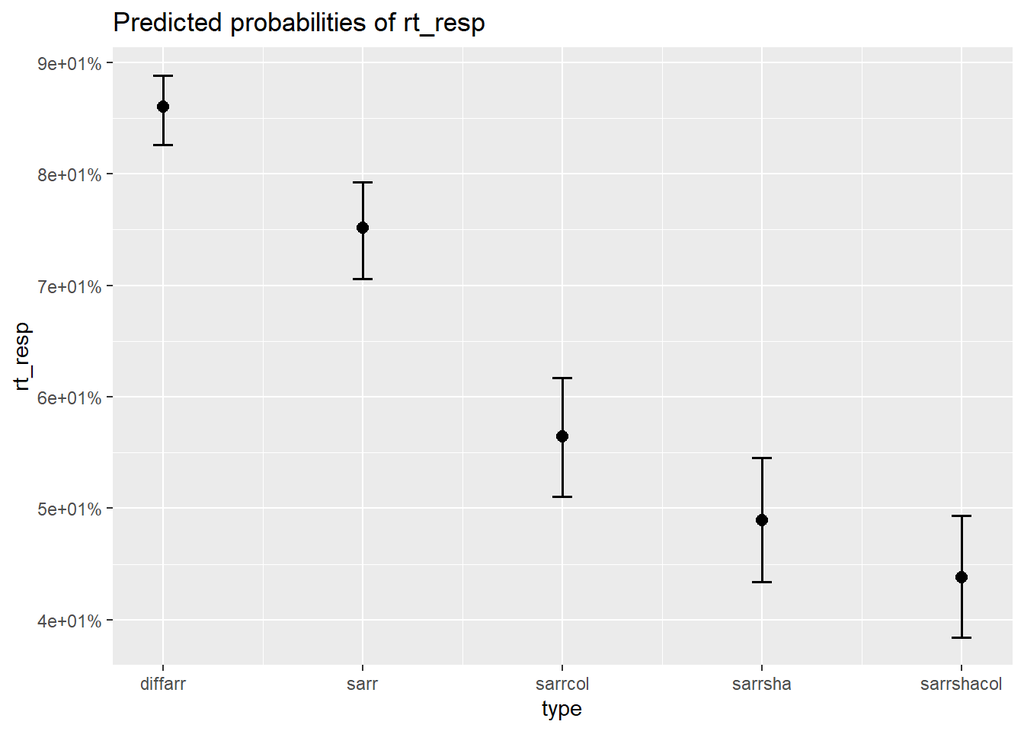

[output not shown]

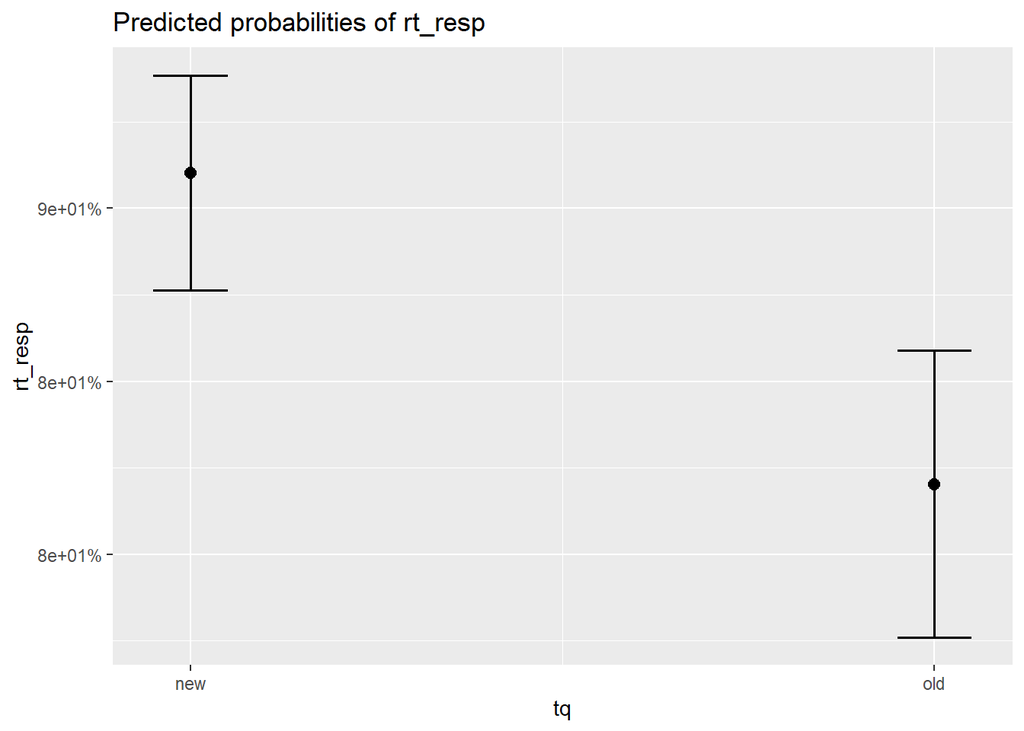

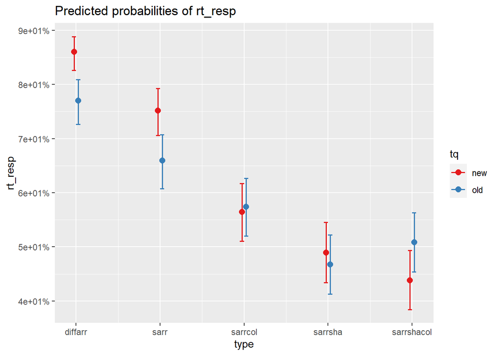

```
## Generalized linear mixed model fit by maximum likelihood (Laplace
##   Approximation) [glmerMod]
##  Family: binomial  ( logit )
## Formula: rt_resp ~ DTF * tq + (1 | workerId)
##    Data: tdlmm
##
##      AIC      BIC   logLik deviance df.resid
##   8710.3   8744.7  -4350.2   8700.3     7159
##
## Scaled residuals:
##     Min      1Q  Median      3Q     Max
## -4.8801 -0.9215  0.4377  0.7799  4.2467
##
## Random effects:
##  Groups   Name        Variance Std.Dev.
##  workerId (Intercept) 0.526    0.7252
## Number of obs: 7164, groups:  workerId, 87
##
## Fixed effects:
##              Estimate Std. Error z value Pr(>|z|)
## (Intercept) -0.390729   0.101719  -3.841 0.000122 ***
## DTF          0.137933   0.008906  15.488  < 2e-16 ***
## tqold        0.241379   0.087956   2.744 0.006063 **
## DTF:tqold   -0.055290   0.011557  -4.784 1.72e-06 ***
## ---
## Signif. codes:  0 '***' 0.001 '**' 0.01 '*' 0.05 '.' 0.1 ' ' 1
##
## Correlation of Fixed Effects:
##           (Intr) DTF    tqold
## DTF       -0.524
## tqold     -0.476  0.603
## DTF:tqold  0.402 -0.766 -0.804
```

[output not shown]

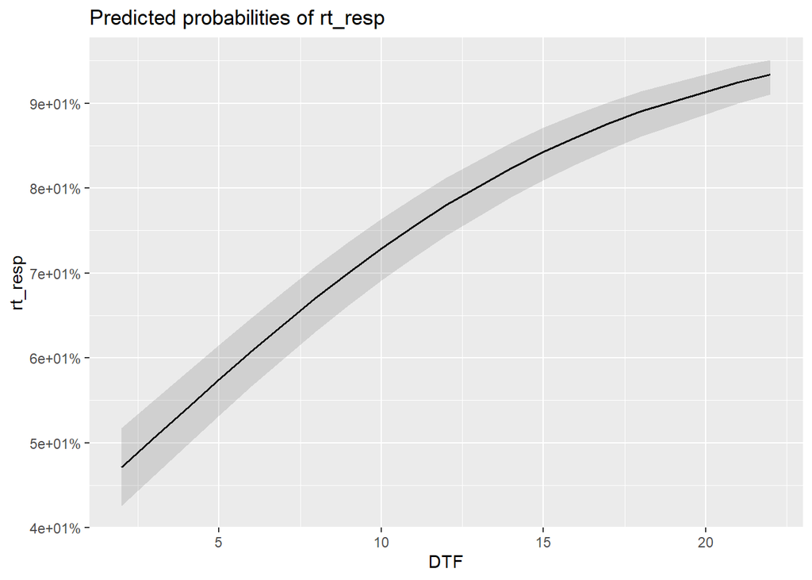

[output not shown]

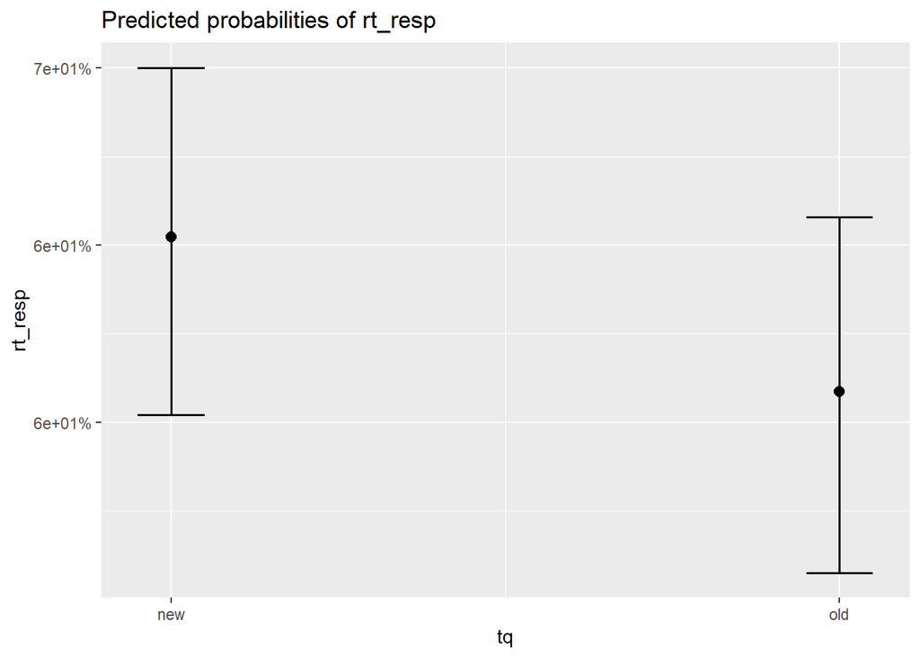

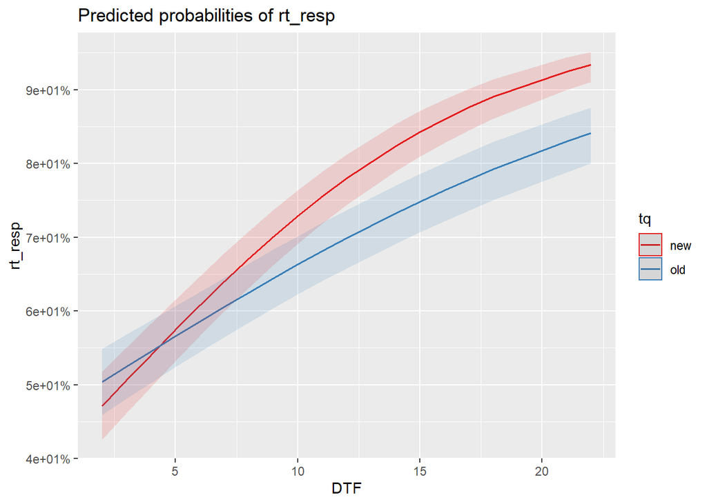

```
## Generalized linear mixed model fit by maximum likelihood (Laplace
##   Approximation) [glmerMod]
##  Family: binomial  ( logit )
## Formula: rt_resp ~ DTAF * tq + (1 | workerId)
##    Data: tdlmm
##
##      AIC      BIC   logLik deviance df.resid
##   8718.2   8752.6  -4354.1   8708.2     7159
##
## Scaled residuals:
##     Min      1Q  Median      3Q     Max
## -4.8522 -0.9236  0.4435  0.7794  3.5743
##
## Random effects:
##  Groups   Name        Variance Std.Dev.
##  workerId (Intercept) 0.5185   0.7201
## Number of obs: 7164, groups:  workerId, 87
##
## Fixed effects:
##             Estimate Std. Error z value Pr(>|z|)
## (Intercept) -2.48124    0.21011 -11.809  < 2e-16 ***
## DTAF         0.23425    0.01533  15.284  < 2e-16 ***
## tqold        0.83048    0.26250   3.164 0.001558 **
## DTAF:tqold  -0.07411    0.02048  -3.618 0.000297 ***
## ---
## Signif. codes:  0 '***' 0.001 '**' 0.01 '*' 0.05 '.' 0.1 ' ' 1
##
## Correlation of Fixed Effects:
##            (Intr) DTAF   tqold
## DTAF       -0.912
## tqold      -0.689  0.726
## DTAF:tqold  0.679 -0.744 -0.980
```